# Video Game Sales Analysis

Dejan Kelecevic

09-12-2025

# Introduction

Video games have become a significant part of the entertainment industry, generating billions of dollars in revenue each year. Understanding the trends and patterns in video game sales can provide valuable insights for developers, publishers, marketers, and researchers.

In this analysis, we use the Video Game Sales dataset from Kaggle, which includes information on game titles, platforms, release years, genres, publishers, and sales figures across different regions (North America, Europe, Japan, and others) as well as global sales.

The goals of this analysis are to explore the dataset, clean the data, perform analysis, and visualize the findings to gain insights into the video game market.

# Setup

```r
library(readr)
library(ggplot2)
library(dplyr)

df <- read_csv("vgsales.csv")
```

# Data Exploration

```r
str(df)
```

```
## spc_tbl_ [16,598 × 11] (S3: spec_tbl_df/tbl_df/tbl/data.frame)
##  $ Rank        : num [1:16598] 1 2 3 4 5 6 7 8 9 10 ...
##  $ Name        : chr [1:16598] "Wii Sports" "Super Mario Bros." "Mario Kart Wii" "Wii Sports Resort" ...
##  $ Platform    : chr [1:16598] "Wii" "NES" "Wii" "Wii" ...
##  $ Year        : chr [1:16598] "2006" "1985" "2008" "2009" ...
##  $ Genre       : chr [1:16598] "Sports" "Platform" "Racing" "Sports" ...
##  $ Publisher   : chr [1:16598] "Nintendo" "Nintendo" "Nintendo" "Nintendo" ...
##  $ NA_Sales    : num [1:16598] 41.5 29.1 15.8 15.8 11.3 ...
##  $ EU_Sales    : num [1:16598] 29.02 3.58 12.88 11.01 8.89 ...
##  $ JP_Sales    : num [1:16598] 3.77 6.81 3.79 3.28 10.22 ...
##  $ Other_Sales : num [1:16598] 8.46 0.77 3.31 2.96 1 0.58 2.9 2.85 2.26 0.47 ...
##  $ Global_Sales: num [1:16598] 82.7 40.2 35.8 33 31.4 ...
##  - attr(*, "spec")=
##   .. cols(
##   ..   Rank = col_double(),
##   ..   Name = col_character(),
##   ..   Platform = col_character(),
##   ..   Year = col_character(),
##   ..   Genre = col_character(),
##   ..   Publisher = col_character(),
##   ..   NA_Sales = col_double(),
##   ..   EU_Sales = col_double(),
##   ..   JP_Sales = col_double(),
##   ..   Other_Sales = col_double(),
##   ..   Global_Sales = col_double()
##   .. )
##  - attr(*, "problems")=<externalptr>
```

```r
summary(df)
```

```
##       Rank           Name             Platform             Year
##  Min.   :    1   Length:16598       Length:16598       Length:16598
##  1st Qu.: 4151   Class :character   Class :character   Class :character
##  Median : 8300   Mode  :character   Mode  :character   Mode  :character
##  Mean   : 8301
##  3rd Qu.:12450
##  Max.   :16600
##     Genre            Publisher            NA_Sales          EU_Sales
##  Length:16598       Length:16598       Min.   : 0.0000   Min.   : 0.0000
##  Class :character   Class :character   1st Qu.: 0.0000   1st Qu.: 0.0000
##  Mode  :character   Mode  :character   Median : 0.0800   Median : 0.0200
##                                        Mean   : 0.2647   Mean   : 0.1467
##                                        3rd Qu.: 0.2400   3rd Qu.: 0.1100
##                                        Max.   :41.4900   Max.   :29.0200
##     JP_Sales         Other_Sales        Global_Sales
##  Min.   : 0.00000   Min.   : 0.00000   Min.   : 0.0100
##  1st Qu.: 0.00000   1st Qu.: 0.00000   1st Qu.: 0.0600
##  Median : 0.00000   Median : 0.01000   Median : 0.1700
##  Mean   : 0.07778   Mean   : 0.04806   Mean   : 0.5374
##  3rd Qu.: 0.04000   3rd Qu.: 0.04000   3rd Qu.: 0.4700
##  Max.   :10.22000   Max.   :10.57000   Max.   :82.7400
```

```r
head(df)
```

```
## # A tibble: 6 × 11
##    Rank Name           Platform Year  Genre Publisher NA_Sales EU_Sales JP_Sales
##   <dbl> <chr>          <chr>    <chr> <chr> <chr>        <dbl>    <dbl>    <dbl>
## 1     1 Wii Sports     Wii      2006  Spor… Nintendo      41.5    29.0      3.77
## 2     2 Super Mario B… NES      1985  Plat… Nintendo      29.1     3.58     6.81
## 3     3 Mario Kart Wii Wii      2008  Raci… Nintendo      15.8    12.9      3.79
## 4     4 Wii Sports Re… Wii      2009  Spor… Nintendo      15.8    11.0      3.28
## 5     5 Pokemon Red/P… GB       1996  Role… Nintendo      11.3     8.89    10.2
## 6     6 Tetris         GB       1989  Puzz… Nintendo      23.2     2.26     4.22
## # ℹ 2 more variables: Other_Sales <dbl>, Global_Sales <dbl>
```

# Data Cleaning

```r
# Check missing values
colSums(is.na(df))
```

```
##         Rank         Name     Platform         Year        Genre    Publisher
##            0            0            0            0            0            0
##     NA_Sales     EU_Sales     JP_Sales  Other_Sales Global_Sales
##            0            0            0            0            0
```

```r
# Remove missing and duplicate rows
df_cleaned <- na.omit(df)
df_cleaned <- df_cleaned[!duplicated(df_cleaned), ]

# Ensure correct data types
df_cleaned$Rank         <- as.integer(df_cleaned$Rank)
df_cleaned$Year         <- as.integer(df_cleaned$Year)
df_cleaned$NA_Sales     <- as.numeric(df_cleaned$NA_Sales)
df_cleaned$EU_Sales     <- as.numeric(df_cleaned$EU_Sales)
df_cleaned$JP_Sales     <- as.numeric(df_cleaned$JP_Sales)
df_cleaned$Other_Sales  <- as.numeric(df_cleaned$Other_Sales)
df_cleaned$Global_Sales <- as.numeric(df_cleaned$Global_Sales)

cat("Rows after cleaning:", nrow(df_cleaned), "\n")
```

```
## Rows after cleaning: 16598
```

# Analysis & Visualisation

## Games Released Per Year

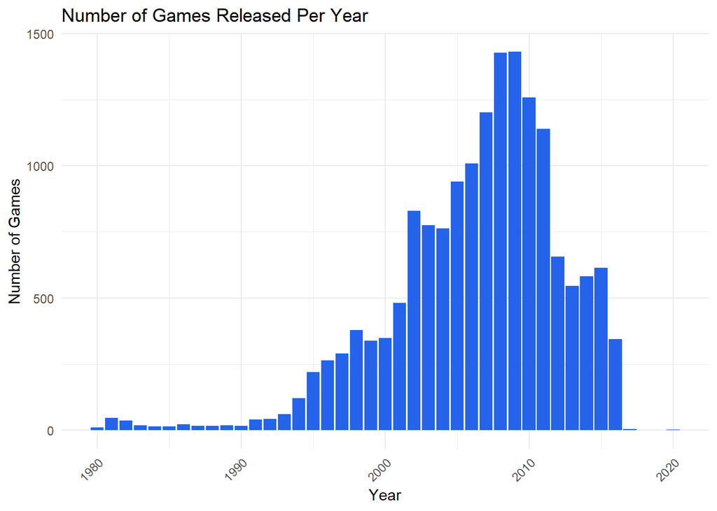

```r
games_per_year <- df_cleaned %>%
  count(Year) %>%
  rename(Frequency = n)

ggplot(games_per_year, aes(x = Year, y = Frequency)) +
  geom_bar(stat = "identity", fill = "#2563EB") +
  labs(title = "Number of Games Released Per Year",
       x = "Year", y = "Number of Games") +
  theme_minimal() +
  theme(axis.text.x = element_text(angle = 45, hjust = 1))
```

## Top 10 Games by Global Sales

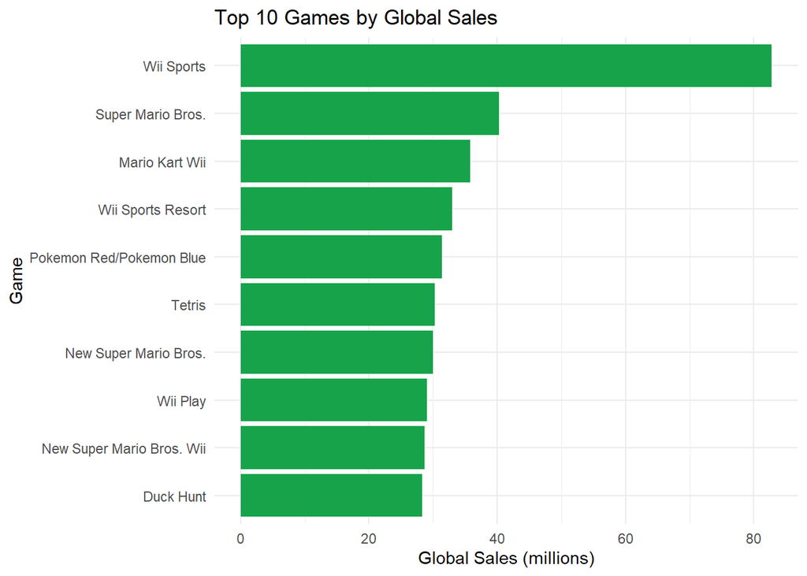

```r
top_10_games <- df_cleaned %>%
  arrange(desc(Global_Sales)) %>%
  slice(1:10)

ggplot(top_10_games, aes(x = reorder(Name, Global_Sales), y = Global_Sales)) +
  geom_bar(stat = "identity", fill = "#16A34A") +
  coord_flip() +
  labs(title = "Top 10 Games by Global Sales",
       x = "Game", y = "Global Sales (millions)") +
  theme_minimal()
```

## Total Sales by Region

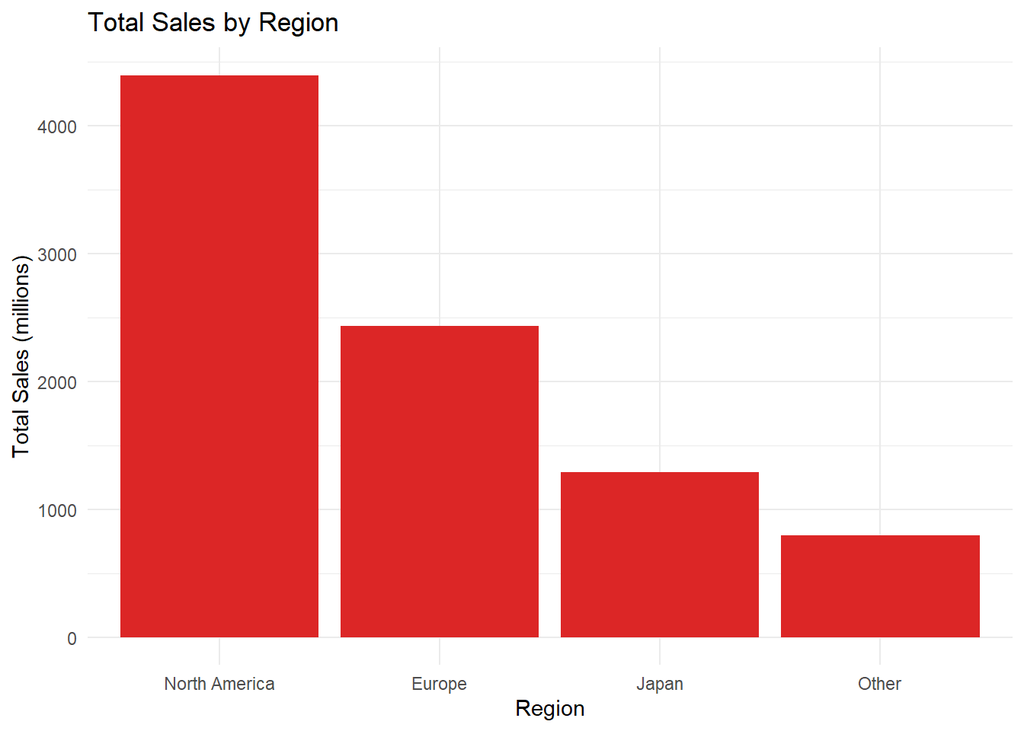

```r
region_sales <- data.frame(
  Region = c("North America", "Europe", "Japan", "Other"),
  Sales  = c(sum(df_cleaned$NA_Sales), sum(df_cleaned$EU_Sales),
             sum(df_cleaned$JP_Sales), sum(df_cleaned$Other_Sales))
)

ggplot(region_sales, aes(x = reorder(Region, -Sales), y = Sales)) +
  geom_bar(stat = "identity", fill = "#DC2626") +
  labs(title = "Total Sales by Region",
       x = "Region", y = "Total Sales (millions)") +
  theme_minimal()
```

## Top 10 Genres by Global Sales

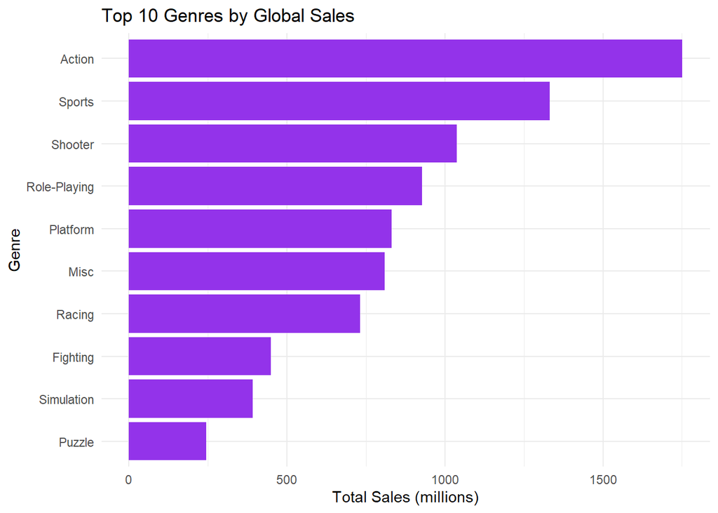

```r
genre_sales <- df_cleaned %>%
  group_by(Genre) %>%
  summarise(Total_Sales = sum(Global_Sales)) %>%
  arrange(desc(Total_Sales)) %>%
  slice(1:10)

ggplot(genre_sales, aes(x = reorder(Genre, Total_Sales), y = Total_Sales)) +
  geom_bar(stat = "identity", fill = "#9333EA") +
  coord_flip() +
  labs(title = "Top 10 Genres by Global Sales",
       x = "Genre", y = "Total Sales (millions)") +
  theme_minimal()
```

## Top 10 Publishers by Global Sales

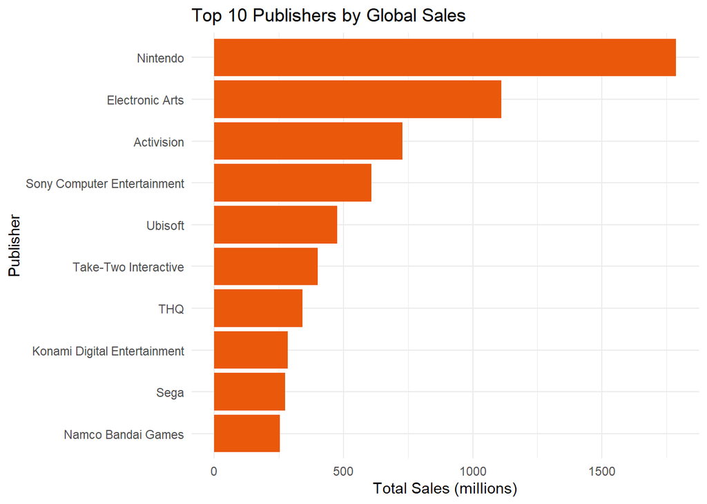

```r
publisher_sales <- df_cleaned %>%
  group_by(Publisher) %>%
  summarise(Total_Sales = sum(Global_Sales)) %>%
  arrange(desc(Total_Sales)) %>%
  slice(1:10)

ggplot(publisher_sales, aes(x = reorder(Publisher, Total_Sales), y = Total_Sales)) +
  geom_bar(stat = "identity", fill = "#EA580C") +
  coord_flip() +
  labs(title = "Top 10 Publishers by Global Sales",
       x = "Publisher", y = "Total Sales (millions)") +
  theme_minimal()
```

# Conclusion

Further analysis could explore platform-specific trends, the rise of specific genres over time, or the correlation between critic scores and sales performance.